# Analysis: Themes and Expertise

Anonymous

This document lays out the thematic analysis and gives some insight into the relation between themes, the AESTHEMOS and Expertise.

# Thematic Analysis

First, two coders individually read through the entire data set to familiarise themselves with the content, and noted down first ideas and observations. We decided to involve two coders, instead of one, as we assumed it will facilitate the theme generating process when more than one coder is familiar with the entire data. Second, the coders were asked to individually generate initial codes that represented the whole data set. Sentences formed the smallest coding units, to which multiple codes could be assigned. Codes were developed regarding the semantic content (i.e., what participants wrote) as well as on latent level (i.e., participants’ assumption underlining the semantic content). After discussing and combining the codes, both coders applied the coding scheme to the entire data set. This was done in order to facilitate finding illustrative quotes when reporting the themes later. The final 69 codes were collided, reevaluated, and merged to initial themes over several discussion sessions among the authors. During this process, the coders draw several thematic maps to consider the relations between the initial themes. Finally, one coder applied the initial themes to the entire data set to ensure the themes cover all instances, and drew a thematic map of the final themes.

The inductive thematic analyses resulted in a final set of seven themes: Appreciating the Craft and Artisanship; Expressive Potential of Games; Awe and Wanderlust; Getting Getting The Feels; Makes You Think; Room for Interpretation; All Games are Art.

## Did Professionals name more topics:

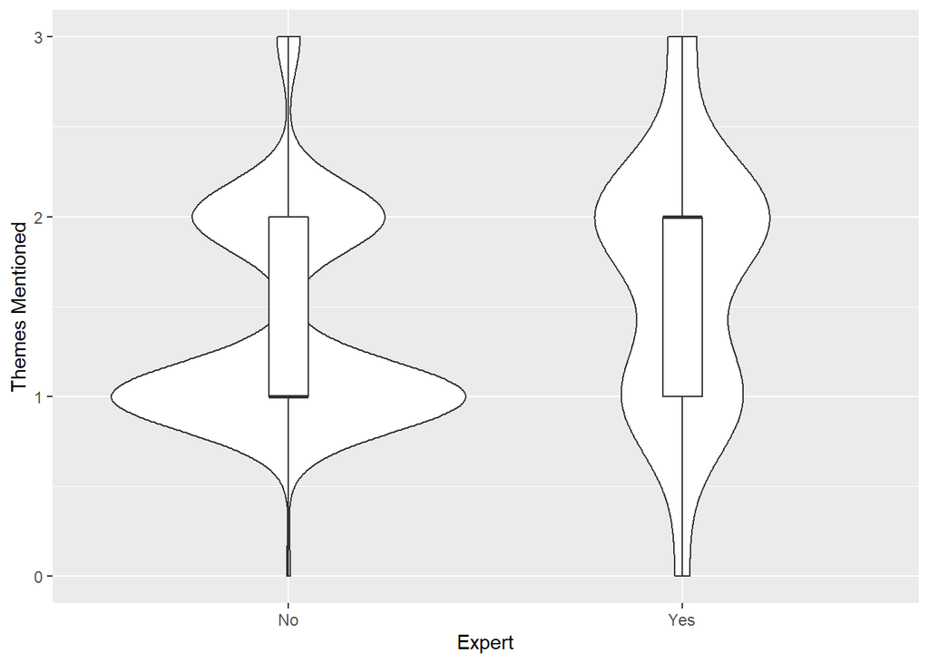

Of our 174 participants, 2 mentioned 0, 101 mentioned 1, 63 mentioned 2, and 8 mentioned 3 themes.

## Which Themes were mentioned how often by which group?

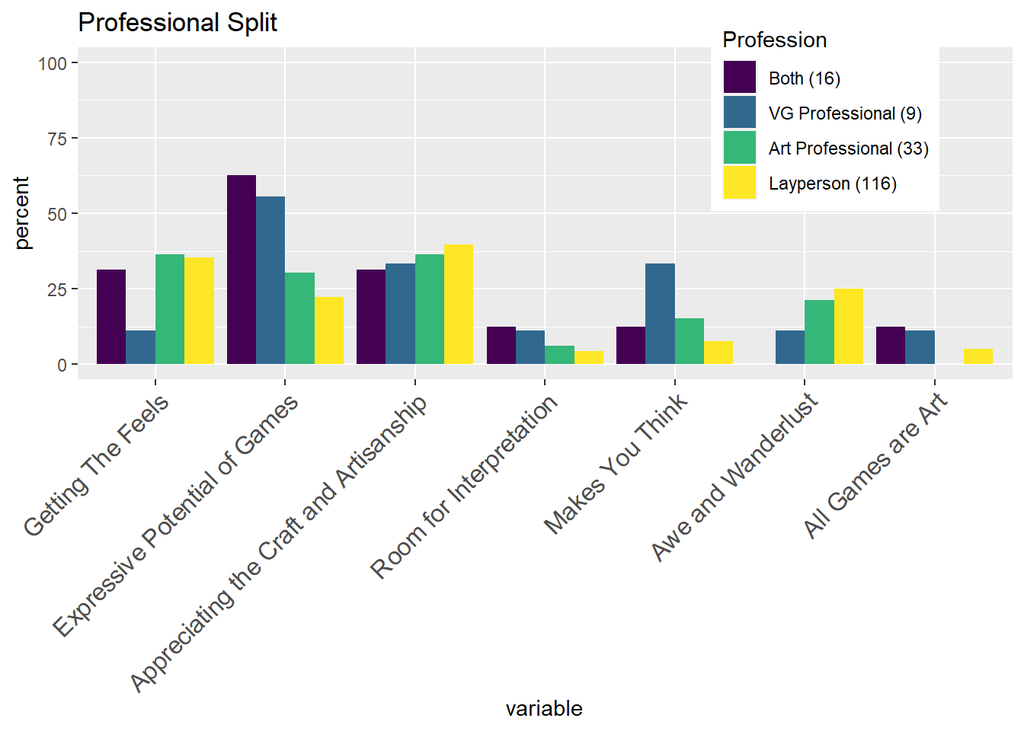

Split by person identifying as a professional member of the games industry or the art industry and by people who identify as neither:

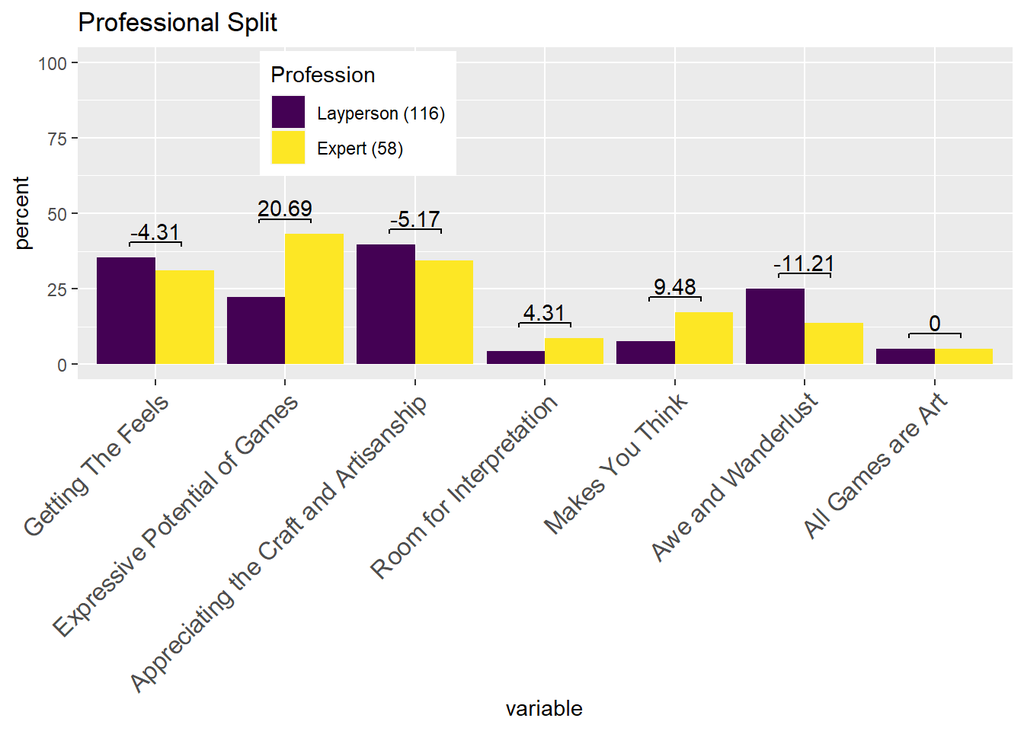

## Self Reported Expertise

As professionalism does not have an exclusivity to expertise, we further looked at the self reported expertise:

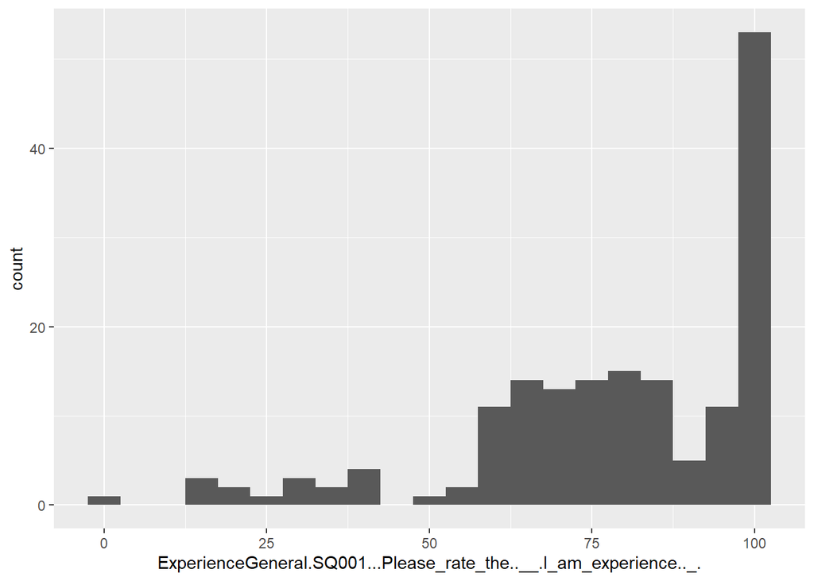

```
## $x
## [1] "Self Reported Experience"
##
## attr(,"class")
## [1] "labels"
```

We perform a median (82) split to differentiate between self reported experts (83) and non-experts(86):

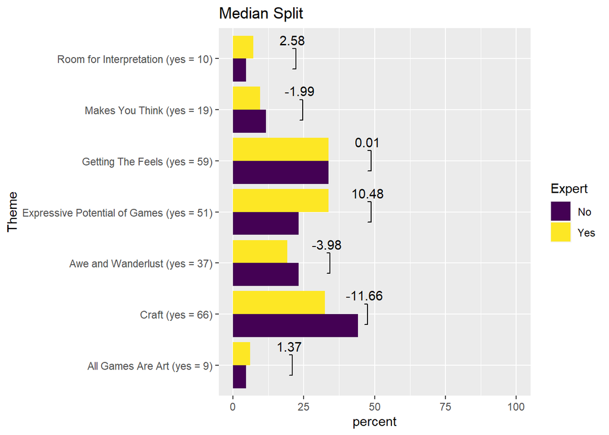

Therefore we further performed a split around the mean (78.72) resulting in 96 experts and 73 non-experts:

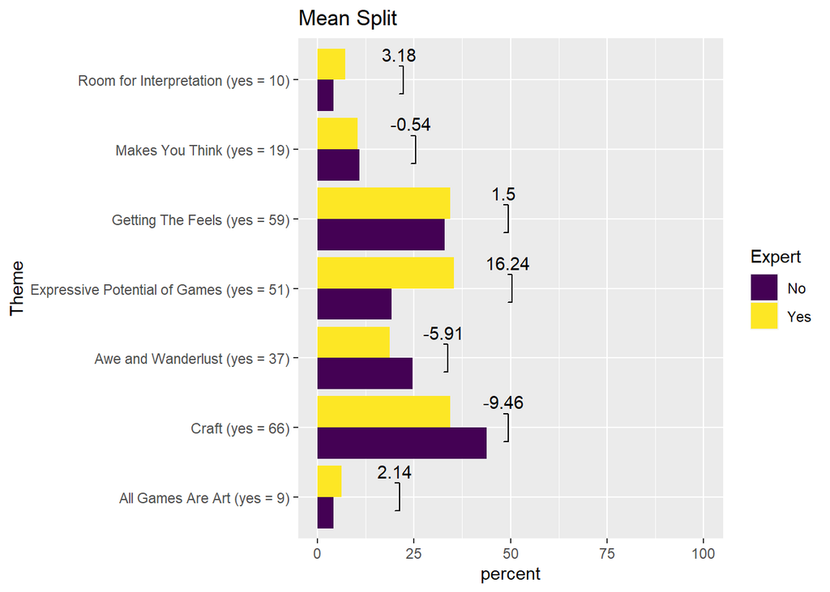

And the middle of the scale (50) resulting in 152 experts and 17 non-experts:

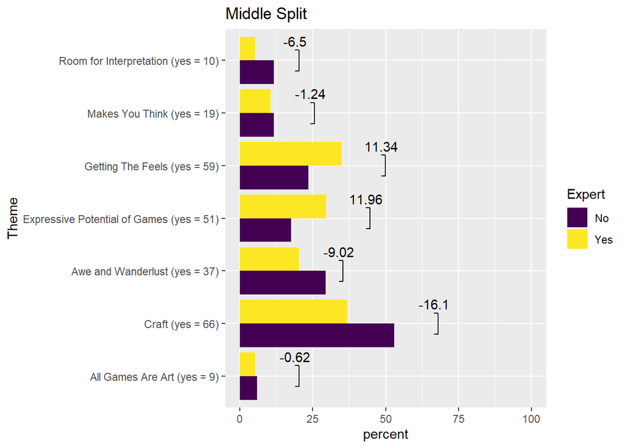

## Relationship between the Themes

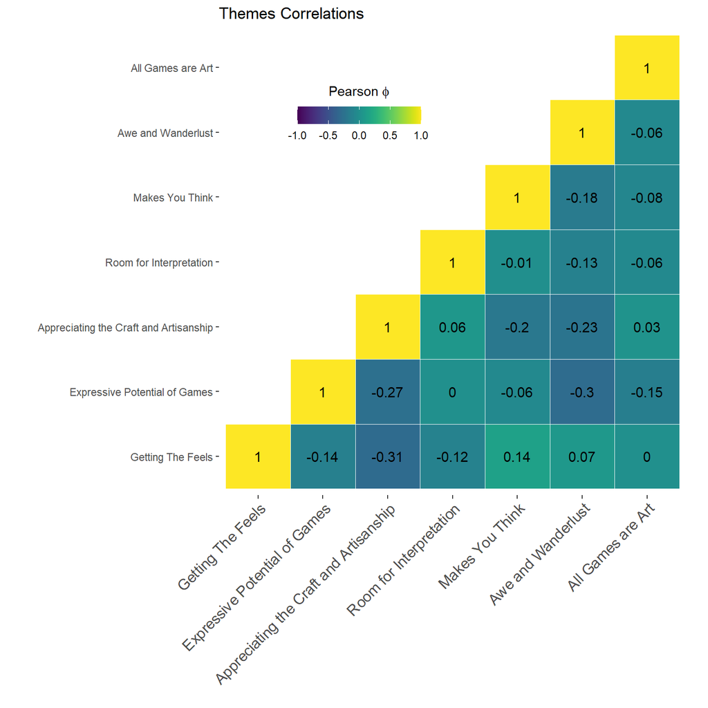

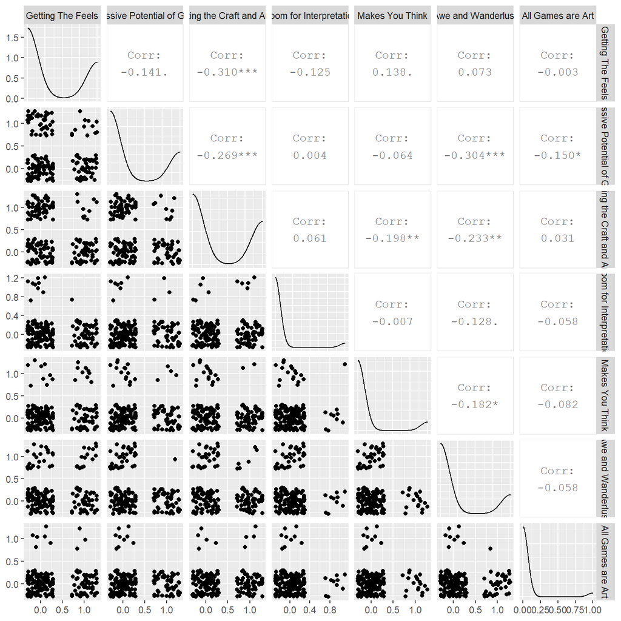

## AESTHEMOS Mean and CIs for each Theme

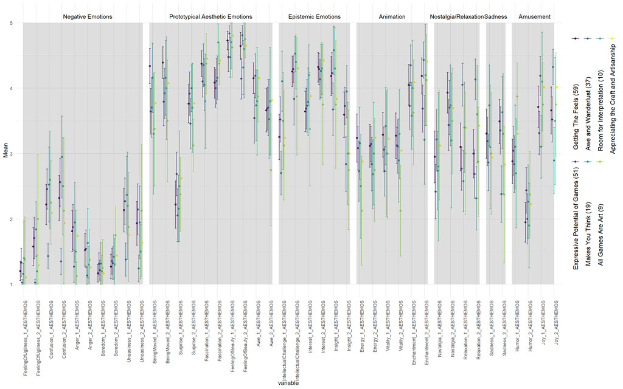

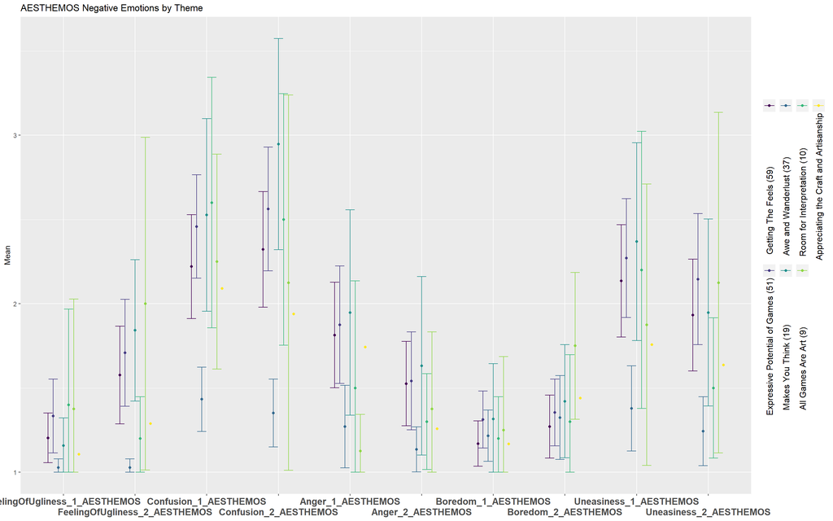

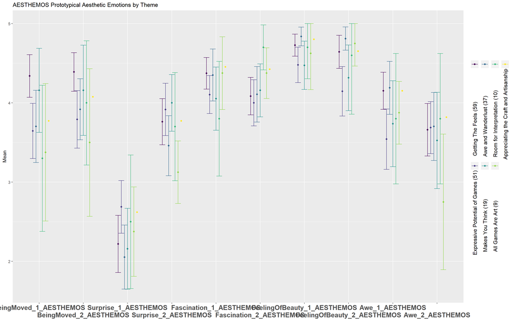

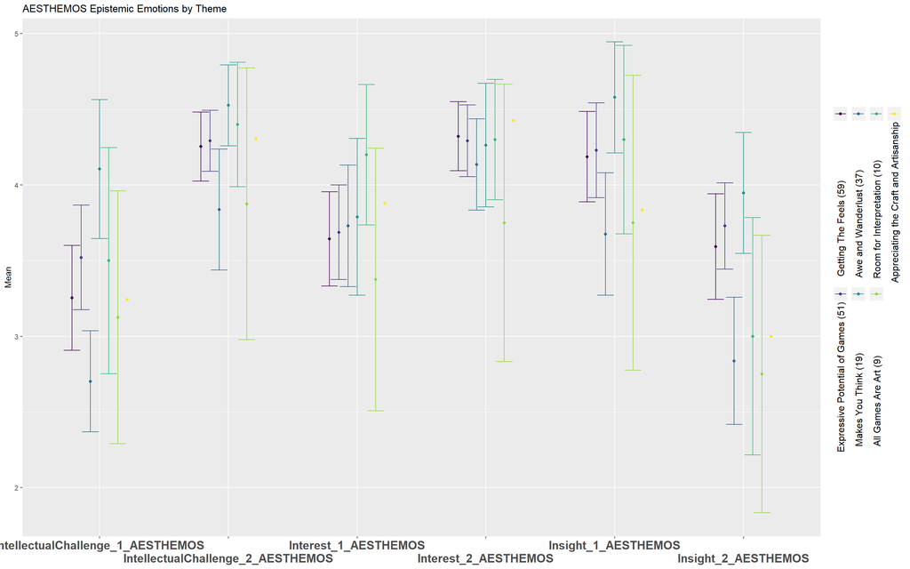

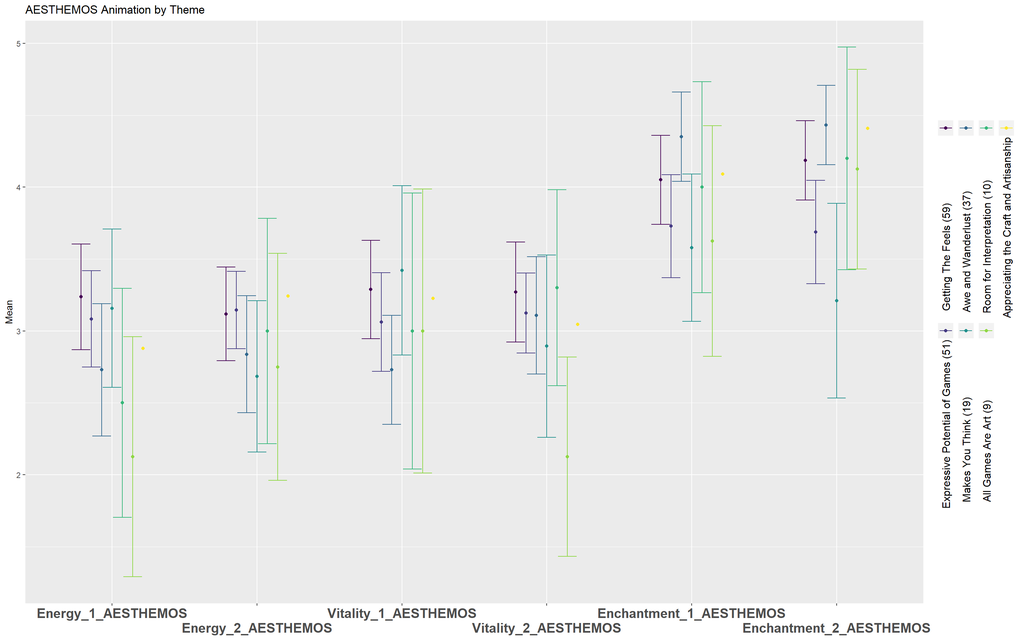

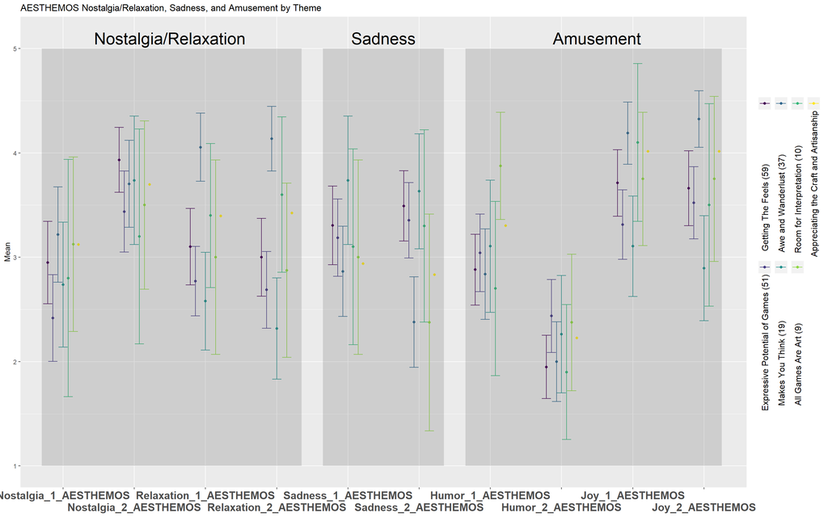

## Each AESTHEMOS item per Theme

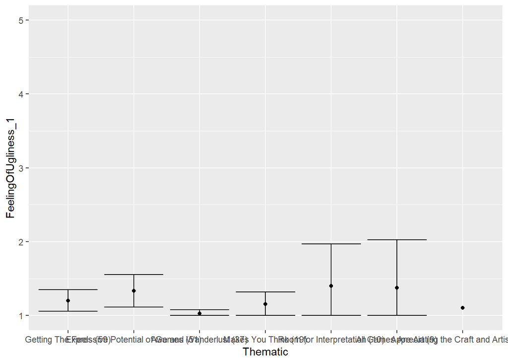

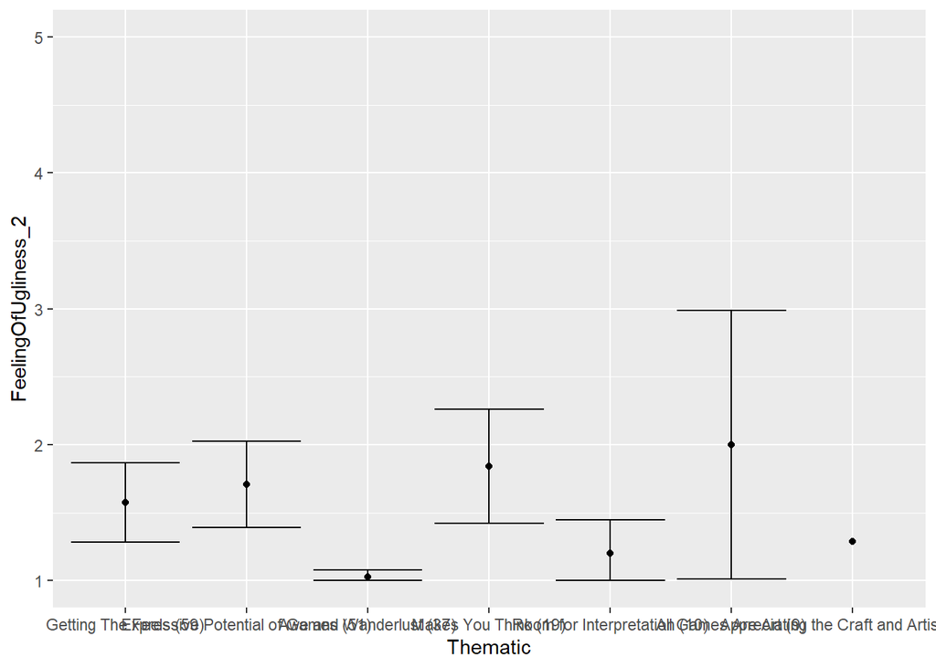

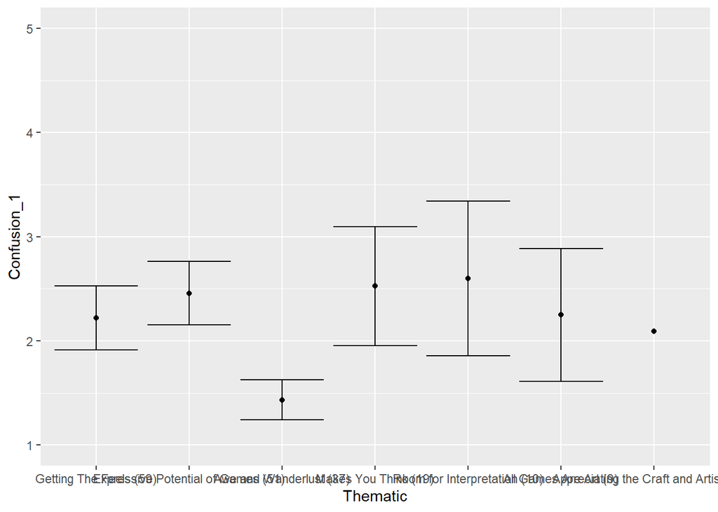

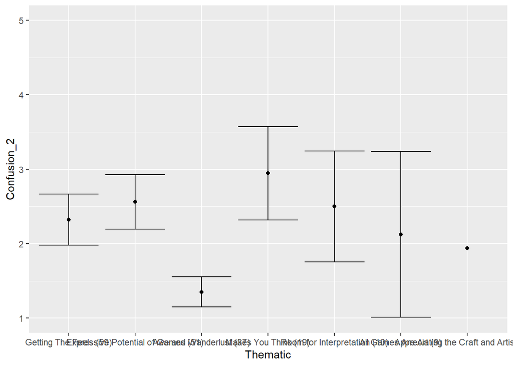

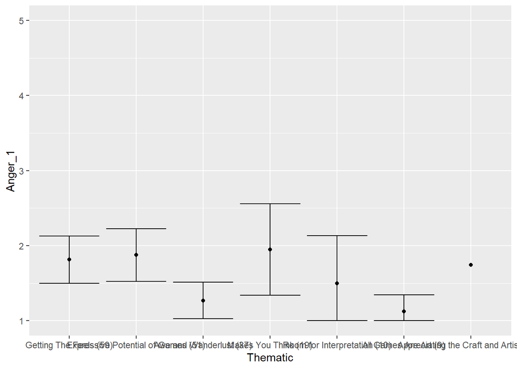

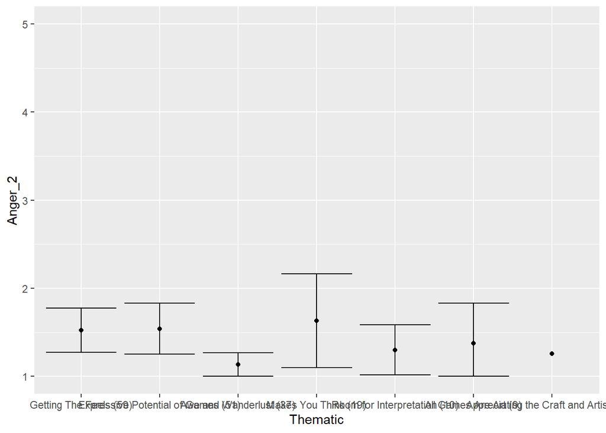

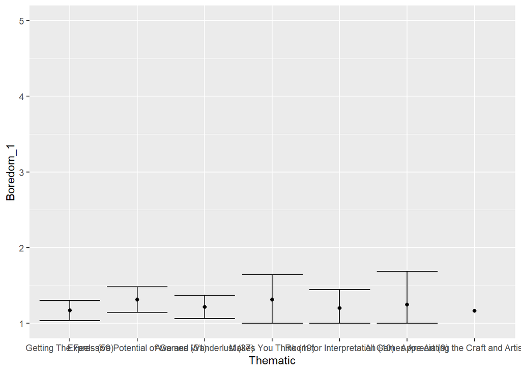

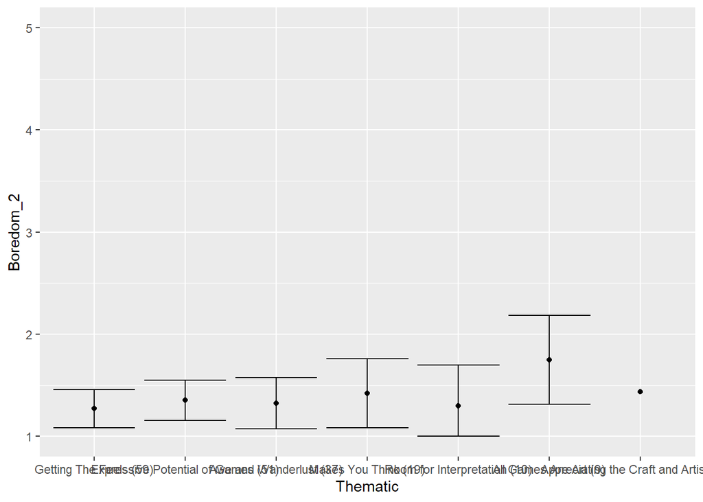

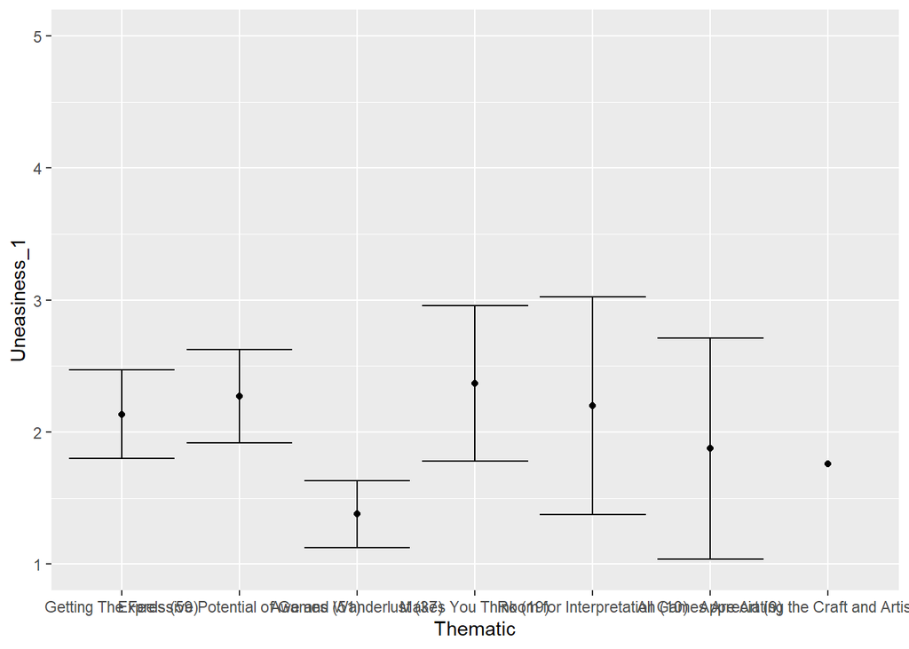

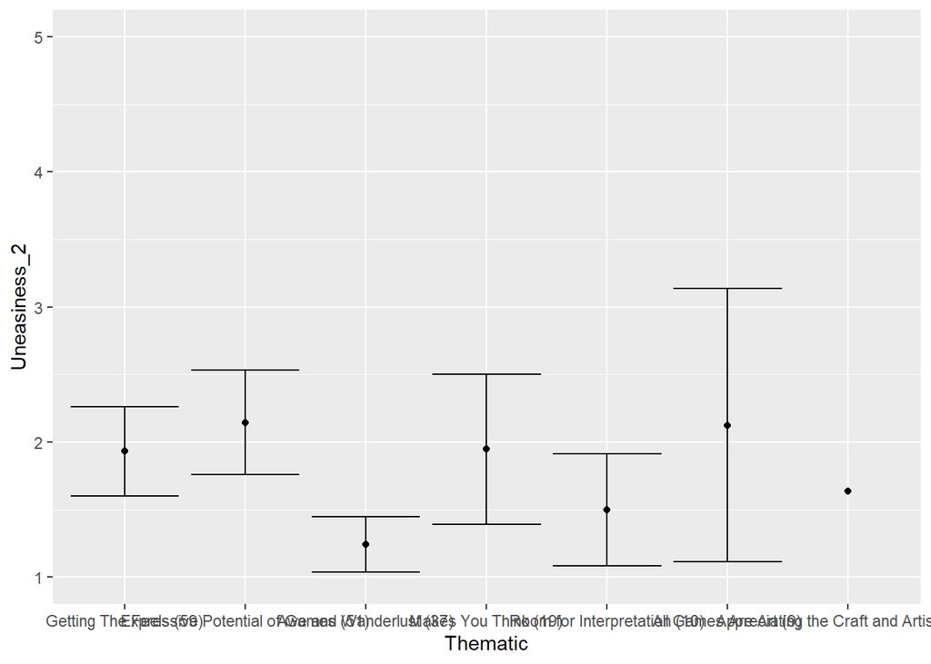

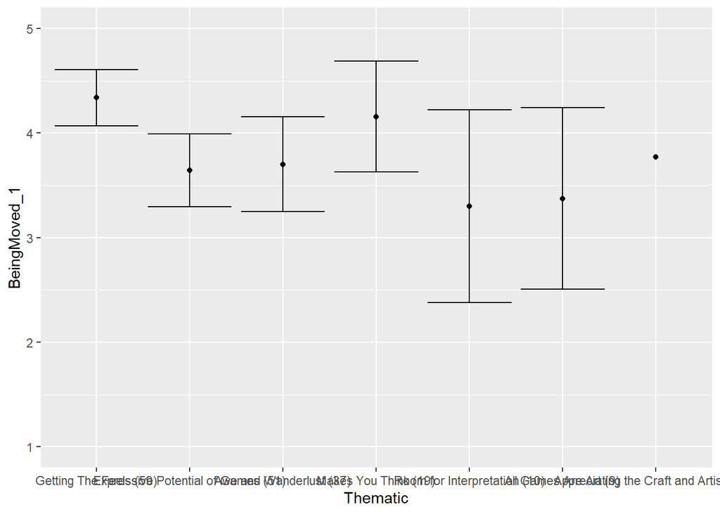

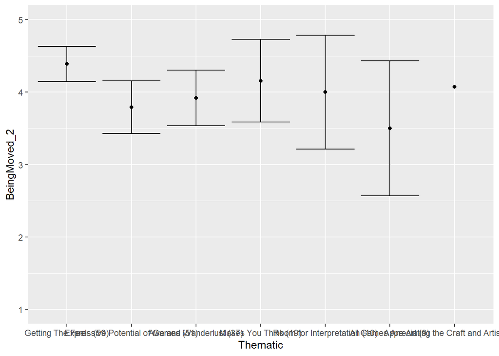

[30 more figures not shown]

# References

1.Virginia Braun and Victoria Clarke. 2006. Using thematic analysis in psychology. Qualitative research in psychology 3, 2: 77–101. https://doi.org/10.1191/1478088706qp063oa

2.Virginia Braun and Victoria Clarke. 2020. One size fits all? What counts as quality practice in (reflexive) thematic analysis? Qualitative Research in Psychology: 1–25.